# Project2

Gaoyuan ZHANG(22994257)

2022-10-16

# Introduction

This project selected the “US Accident Injury Dataset” dataset from Data.gov, which is published by the US Department of Labour and spans 15 years (from 2000 to 2015). This dataset contains information on all accidents, injuries, and illnesses reported by mine operators and contractors. For project2, I use the data and domain I have explored in Project 1.

## Load libraries

```r
library(knitr)
library(kableExtra)
library(ggthemes)
library(rpart)
library(grid)
library(ggplot2)
library(gridExtra)
library(tidyverse)
library(data.table)
library(timeDate)
library(lubridate)
library(reshape2)
library(vtreat)
library(magrittr)
library(ROCR)
library(dplyr)
library(ca)
library(numform)
library(tidyr)
library(ape)
library(ROCit)
library(xgboost)
library(factoextra)
library(cluster)
library(NbClust)
library(gridExtra)
library(fpc)
```

## Setting up a plotting theme so that all charts look coherent

```r
project_theme <- theme_few() +
                  theme(plot.title = element_text(color = "darkred")) +
                  theme(strip.text.x = element_text(size = 16, colour = "#202020")) +
                  theme(plot.margin=ggplot2::margin(10,30,10,30))
```

# Part1 Classification

## Overview

In this part, our goal is to define an accident by predicting its severity based on a number of variables. We define DAYS_AFFECT = (0.5 * DAYS_RESTRICT + DAYS_LOST) * NO_INJURIES and divide it into two categories [0, 8) and [8, inf), which respectively denote unaffected accident and affected accident.

## Data preparation

### Data Cleaning

In order to measure the severity of an accident, it is necessary for us to use the column DAYS_RESTRICT, DAYS_LOST and NO_INJURIES, which mean the number of days of restricted work activity, the number of actual days lost from work and the number of reportable injuries or illnesses resulting from the accident.

```r
us_data <- read.csv("us_data_full.csv")
data_classification <- us_data

# Replace some missing values with mean

group1 <- data_classification %>%
        group_by(DEGREE_INJURY) %>%
        summarise(NO_INJURIES = mean(NO_INJURIES, na.rm = T))
group2 <- data_classification %>%
        group_by(DEGREE_INJURY) %>%
        summarise(DAYS_RESTRICT = mean(DAYS_RESTRICT, na.rm = T))
group3 <- data_classification %>%
        group_by(DEGREE_INJURY) %>%
        summarise(DAYS_LOST = mean(DAYS_LOST, na.rm = T))

mean_NO_INJURIES <- mean(data_classification$NO_INJURIES, na.rm=T)
data_classification$NO_INJURIES <-
  ifelse(is.na(data_classification$NO_INJURIES),mean_NO_INJURIES,data_classification$NO_INJURIES)
mean_DAYS_RESTRICT <- mean(data_classification$DAYS_RESTRICT, na.rm=T)
data_classification$DAYS_RESTRICT <-
  ifelse(is.na(data_classification$DAYS_RESTRICT),mean_DAYS_RESTRICT,data_classification$DAYS_RESTRICT)
mean_DAYS_LOST <- mean(data_classification$DAYS_LOST, na.rm=T)
data_classification$DAYS_LOST <-
  ifelse(is.na(data_classification$DAYS_LOST),mean_DAYS_LOST,data_classification$DAYS_LOST)
```

### Define the target variable

Firstly, we indicate a new column DAYS_AFFECT by (0.5 * DAYS_RESTRICT + DAYS_LOST) * NO_INJURIES. Multiplied by the coefficient 0.5 because DAYS_RESTRICT means that it can still partially work, it is not as severe as DAYS_LOST. Next, We can divide it into two categories [0, 8) and [8, inf) with a cut-off of 8, which can keep a good class balance. Finally, because some data from DAYS_RESTRICT and DAYS_LOST is NA, we should filter some data.

```r
data_classification <-  data_classification %>% mutate(DAYS_AFFECT = (DAYS_RESTRICT * 0.5 + DAYS_LOST) * NO_INJURIES ) %>%  mutate(DAYS_AFFECT_CLASS = cut(DAYS_AFFECT, breaks = c(0, 8, Inf), include.lowest=T, right=F)) %>% filter(!is.na(DAYS_AFFECT_CLASS))

table_affect <- table(data_classification$DAYS_AFFECT_CLASS)
kable(table_affect)
```

| Var1 | Freq |
| --- | --- |
| [0,8) | 102561 |
| [8,Inf] | 100253 |

102561 and 100253 are very close, which can keep a balance and significantly affect the model.

```r
round(prop.table(table_affect), 4)
```

```
##
##   [0,8) [8,Inf]
##  0.5057  0.4943
```

### Select some variables and check their relation with accident

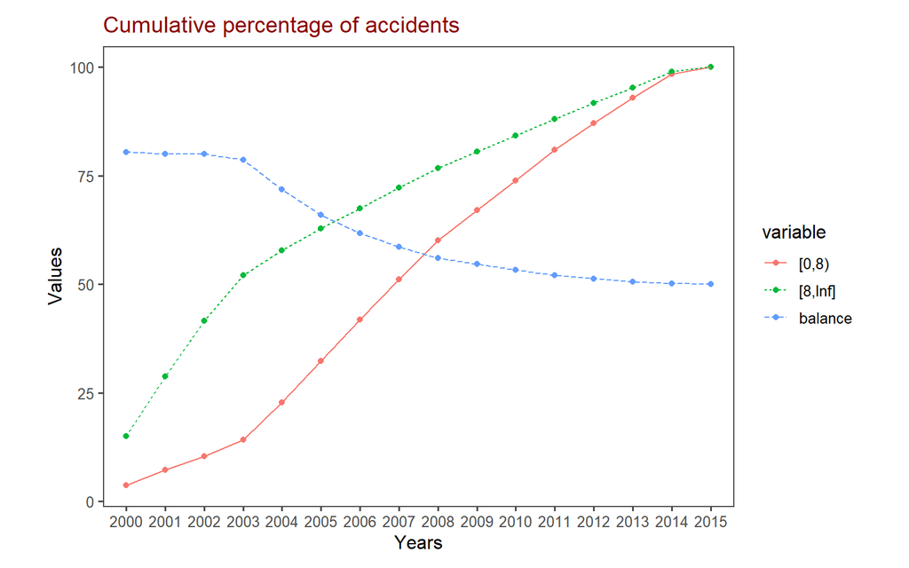

```r
cand.columns <- c("MINE_ID", "CONTROLLER_ID", "CONTROLLER_NAME","OPERATOR_ID", "OPERATOR_NAME","SUBUNIT","CAL_YR","CAL_QTR",
                       "FISCAL_YR","FISCAL_QTR","ACCIDENT_TIME","FIPS_STATE_CD", "DEGREE_INJURY",
                       "UG_LOCATION","UG_MINING_METHOD","MINING_EQUIP","EQUIP_MFR_NAME",
                       "SHIFT_BEGIN_TIME","CLASSIFICATION","ACCIDENT_TYPE", "NO_INJURIES",
                       "TOT_EXPER","MINE_EXPER","JOB_EXPER","OCCUPATION","ACTIVITY",
                       "INJURY_SOURCE","NATURE_INJURY","INJ_BODY_PART","SCHEDULE_CHARGE",
                       "IMMED_NOTIFY", "DAYS_LOST")

outcome <- 'DAYS_AFFECT_CLASS'
data <- data_classification[,c(outcome, cand.columns)]
pos.label <- "[8,Inf]"

col_num <- which(colnames(data) %in%
c("MINE_ID", "CAL_YR","CAL_QTR","FISCAL_YR","FISCAL_QTR","ACCIDENT_TIME","FIPS_STATE_CD","EQUIP_MODEL_NO","SHIFT_BEGIN_TIME","NO_INJURIES","TOT_EXPER","MINE_EXPER","JOB_EXPER","SCHEDULE_CHARGE", "DAYS_RESTRICT", "DAYS_LOST"))

data[,-col_num] <- lapply(data[,-col_num] , factor)

acc_per_year <- as.matrix(table(data[,outcome], data$CAL_YR))

cummulative <- as.data.frame(t(t(apply(acc_per_year,1,cumsum))/apply(acc_per_year,1,sum)*100))
cummulative$year <- rownames(cummulative)
cummulative$balance <-100*cummulative$`[8,Inf]`/(cummulative$`[0,8)`+cummulative$`[8,Inf]`)

ggplot(melt(cummulative), aes(x=year,y=value,group=variable,colour=variable)) +
  geom_point()+
  labs(x = "Years", y = "Values", title= "Cumulative percentage of accidents") +
  theme(axis.text.x = element_text(angle = 90, hjust = 1)) +
  geom_line(aes(lty=variable)) +
  project_theme
```

### Splitting the data

Therefore, we can use CAL_YR to split the data into three sets: training(2000-2010), calibration(2011-2013), and test(2014-2015)

```r
split.train.cal.test <- function(x, split.column='CAL_YR', train.split.value=2010, cal.split.value=2013){
 rvalue <- x[,split.column]
 list( x[rvalue <= train.split.value, ],
 x[rvalue > train.split.value & rvalue <= cal.split.value, ],
 x[rvalue > cal.split.value, ])
}

splits <- split.train.cal.test(data, split.column='CAL_YR', train.split.value=2010, cal.split.value=2013)
dTrain <- splits[[1]]
dCal <- splits[[2]]
dTest <- splits[[3]]

lapply(splits,nrow)
```

```
## [[1]]
## [1] 160248
##
## [[2]]
## [1] 30593
##
## [[3]]
## [1] 11973
```

Training set: 160248; calibration set: 30593; test set: 11973.

## Single variable model

### Evaluation

The functions are used for model building and AUC.

```r
mkPredC <- function(outCol,varCol,appCol, pos=pos.label) {
  pPos <- sum(outCol==pos)/length(outCol)
  naTab <- table(as.factor(outCol[is.na(varCol)]))
  pPosWna <- (naTab/sum(naTab))[pos]
  vTab <- table(as.factor(outCol),varCol)
  pPosWv <- (vTab[pos,]+1.0e-3*pPos)/(colSums(vTab)+1.0e-3)
  pred <- pPosWv[appCol]
  pred[is.na(appCol)] <- pPosWna
  pred[is.na(pred)] <- pPos
  pred
}
mkPredN <- function(outCol,varCol,appCol) {
  cuts <- unique(as.numeric(quantile(varCol, probs=seq(0, 1, 0.1), na.rm=T)))
  varC <- cut(varCol, cuts)
  appC <- cut(appCol, cuts)
  mkPredC(outCol, varC, appC)
}
calcAUC <- function(predcol, outcol, pos=pos.label) {
  perf <- performance(prediction(predcol, outcol==pos),'auc')
  as.numeric(perf@y.values)
}
```

### Model

Create single variable prediction model and evaluate them with AUC.

```r
catvars <- cand.columns[sapply(dTrain[,cand.columns],class) %in% c('factor','character')]

for(v in catvars) {
  pii <- paste('pred',v,sep='')

  dTrain[,pii] <- mkPredC(dTrain[,outcome], dTrain[,v], dTrain[,v])
  dCal[,pii] <- mkPredC(dTrain[,outcome], dTrain[,v], dCal[,v])
  dTest[,pii] <- mkPredC(dTrain[,outcome], dTrain[,v], dTest[,v])
  aucTrain <- calcAUC(dTrain[,pii],dTrain[,outcome])
}

catvars
```

```
##  [1] "CONTROLLER_ID"    "CONTROLLER_NAME"  "OPERATOR_ID"      "OPERATOR_NAME"
##  [5] "SUBUNIT"          "DEGREE_INJURY"    "UG_LOCATION"      "UG_MINING_METHOD"
##  [9] "MINING_EQUIP"     "EQUIP_MFR_NAME"   "CLASSIFICATION"   "ACCIDENT_TYPE"
## [13] "OCCUPATION"       "ACTIVITY"         "INJURY_SOURCE"    "NATURE_INJURY"
## [17] "INJ_BODY_PART"    "IMMED_NOTIFY"
```

```r
numvars <- cand.columns[sapply(dTrain[,cand.columns],class) %in% c('numeric','integer')]

for(v in numvars) {
  pii<-paste('pred',v,sep='')
  dTrain[,pii] <- mkPredN(dTrain[,outcome], dTrain[,v], dTrain[,v])
  dTest[,pii] <- mkPredN(dTrain[,outcome], dTrain[,v], dTest[,v])
  dCal[,pii] <- mkPredN(dTrain[,outcome], dTrain[,v], dCal[,v])
  aucTrain <- calcAUC(dTrain[,pii],dTrain[,outcome])
}

numvars
```

```
##  [1] "MINE_ID"          "CAL_YR"           "CAL_QTR"          "FISCAL_YR"
##  [5] "FISCAL_QTR"       "ACCIDENT_TIME"    "FIPS_STATE_CD"    "SHIFT_BEGIN_TIME"
##  [9] "NO_INJURIES"      "TOT_EXPER"        "MINE_EXPER"       "JOB_EXPER"
## [13] "SCHEDULE_CHARGE"  "DAYS_LOST"
```

### AUC result

Sort and show all the AUC result of signal variable model in a data frame.

```r
all.vars <- c(catvars, numvars)
models.auc <- data.frame(model.type = 'univariate',
                         model.name = all.vars,
                         train.auc = sapply(all.vars, function(v){pii <- paste('pred',v,sep=''); calcAUC(dTrain[,pii], dTrain[,outcome])}),
                         cal.auc = sapply(all.vars, function(v){pii <- paste('pred',v,sep=''); calcAUC(dCal[,pii],dCal[,outcome])}))

kable(models.auc[order(-models.auc$cal.auc), ]) %>%
  kable_styling(bootstrap_options = c("striped", "hover", "condensed", "responsive"))
```

|  | model.type | model.name | train.auc | cal.auc |
| --- | --- | --- | --- | --- |
| DAYS_LOST | univariate | DAYS_LOST | 0.9241345 | 0.8937003 |
| DEGREE_INJURY | univariate | DEGREE_INJURY | 0.7508199 | 0.8818884 |
| NATURE_INJURY | univariate | NATURE_INJURY | 0.7283197 | 0.7790178 |
| INJ_BODY_PART | univariate | INJ_BODY_PART | 0.7199998 | 0.7666708 |
| ACCIDENT_TYPE | univariate | ACCIDENT_TYPE | 0.7092263 | 0.7332957 |
| INJURY_SOURCE | univariate | INJURY_SOURCE | 0.6974993 | 0.7181528 |
| CLASSIFICATION | univariate | CLASSIFICATION | 0.6719221 | 0.6588427 |
| ACTIVITY | univariate | ACTIVITY | 0.6771268 | 0.6520191 |
| TOT_EXPER | univariate | TOT_EXPER | 0.6603877 | 0.6186738 |
| MINE_EXPER | univariate | MINE_EXPER | 0.6534088 | 0.6126233 |
| JOB_EXPER | univariate | JOB_EXPER | 0.6437825 | 0.6031757 |
| OCCUPATION | univariate | OCCUPATION | 0.7350676 | 0.6008850 |
| NO_INJURIES | univariate | NO_INJURIES | 0.6306778 | 0.5878127 |
| IMMED_NOTIFY | univariate | IMMED_NOTIFY | 0.8020372 | 0.5753467 |
| OPERATOR_ID | univariate | OPERATOR_ID | 0.6923592 | 0.5512988 |
| OPERATOR_NAME | univariate | OPERATOR_NAME | 0.7039262 | 0.5494602 |
| MINING_EQUIP | univariate | MINING_EQUIP | 0.5608046 | 0.5451807 |
| CONTROLLER_NAME | univariate | CONTROLLER_NAME | 0.6635977 | 0.5338310 |
| CONTROLLER_ID | univariate | CONTROLLER_ID | 0.6639071 | 0.5338094 |
| UG_LOCATION | univariate | UG_LOCATION | 0.6084865 | 0.5326379 |
| ACCIDENT_TIME | univariate | ACCIDENT_TIME | 0.5226646 | 0.5214925 |
| MINE_ID | univariate | MINE_ID | 0.5446277 | 0.5161229 |
| FISCAL_YR | univariate | FISCAL_YR | 0.7198449 | 0.5135870 |
| SHIFT_BEGIN_TIME | univariate | SHIFT_BEGIN_TIME | 0.5290967 | 0.5115225 |
| CAL_QTR | univariate | CAL_QTR | 0.5216965 | 0.5105582 |
| FISCAL_QTR | univariate | FISCAL_QTR | 0.5216965 | 0.5105582 |
| FIPS_STATE_CD | univariate | FIPS_STATE_CD | 0.5443017 | 0.5090940 |
| SUBUNIT | univariate | SUBUNIT | 0.5577213 | 0.5034651 |
| UG_MINING_METHOD | univariate | UG_MINING_METHOD | 0.5490985 | 0.5017008 |
| CAL_YR | univariate | CAL_YR | 0.7252707 | 0.5000000 |
| SCHEDULE_CHARGE | univariate | SCHEDULE_CHARGE | 0.5016892 | 0.4972972 |
| EQUIP_MFR_NAME | univariate | EQUIP_MFR_NAME | 0.5776874 | 0.4963086 |

## Feature selection with log likelihood

We can use log likelihood to calculate the score of the single variable in calibration set. In order to select the appropriate variable as much as possible, it is critical that it can have a positive effect on the prediction. Therefore, we set the threshold as -1500, and variables with scores > -1500 will be used as feature variables for the prediction of models.

```r
logLikelyhood <- function(outCol, predCol, pos=pos.label) {
  sum(ifelse(outCol==pos, log(predCol), log(1-predCol)))
}

baseRateCheck <- logLikelyhood(dCal[,outcome],  sum(dCal[,outcome]==pos.label)/length(dCal[,outcome]) )

selPredVars <- c()
selVars <- c()
minStep <- -1500

for(v in catvars) {
  pii <- paste('pred',v,sep='')
  liCheck <- 2*((sum(ifelse(dCal[,outcome]==pos.label, log(dCal[,pii]),log(1-dCal[,pii]))) - baseRateCheck))
  if(liCheck > minStep) {
    print(sprintf("%s, calibrationScore: %g",pii,liCheck))
    selPredVars <- c(selPredVars,pii)
    selVars <- c(selVars, v)
  }
}
```

```
## [1] "predDEGREE_INJURY, calibrationScore: 6454.05"
## [1] "predACCIDENT_TYPE, calibrationScore: 1245.2"
## [1] "predOCCUPATION, calibrationScore: -624.123"
## [1] "predACTIVITY, calibrationScore: -985.861"
## [1] "predINJURY_SOURCE, calibrationScore: 547.117"
## [1] "predNATURE_INJURY, calibrationScore: 2618.71"
## [1] "predINJ_BODY_PART, calibrationScore: 1852.67"
## [1] "predIMMED_NOTIFY, calibrationScore: 2241.37"
```

```r
for(v in numvars) {
  pii <- paste('pred',v,sep='')
  liCheck <- 2*((sum(ifelse(dCal[,outcome]==pos.label, log(dCal[,pii]),log(1-dCal[,pii]))) - baseRateCheck) - 1)
  if(liCheck > minStep) {
    print(sprintf("%s, calibrationScore: %g", pii,liCheck))
    selPredVars <- c(selPredVars,pii)
    selVars <- c(selVars, v)
  }
}
```

```
## [1] "predNO_INJURIES, calibrationScore: -1083.37"
## [1] "predDAYS_LOST, calibrationScore: 22557.9"
```

Therefore, these 10 variables below are chosen as feature variables.

```r
print(selVars)
```

```
##  [1] "DEGREE_INJURY" "ACCIDENT_TYPE" "OCCUPATION"    "ACTIVITY"
##  [5] "INJURY_SOURCE" "NATURE_INJURY" "INJ_BODY_PART" "IMMED_NOTIFY"
##  [9] "NO_INJURIES"   "DAYS_LOST"
```

## Multivariate models

### Evaluation

The following functions are created for the different models we will create. This function will return ROC plot, prediction distribution plot, precision / recall plot, confusion matrix and log likelihood.

```r
evaluate_performance <- function(predictions, true.values, do.print=TRUE, threshold.value=0.5, pos=pos.label){
  eval.auc <- calcAUC(predictions, true.values)

  if(do.print){
    # ROC plot
    predObj <- prediction(predictions, true.values)
    perf <- performance(predObj, "tpr", "fpr")
    roc.df <- data.frame('fpr'=unlist(perf@x.values),'tpr'=unlist(perf@y.values),'threshold'=unlist(perf@alpha.values))
    p <- ggplot(roc.df, aes(x=fpr, y=tpr))+
      geom_line() +
      geom_abline(intercept = 0, slope = 1, linetype='dashed') +
      project_theme
    print(p)

    # Prediction distribution plot
    p <- ggplot(data.frame(predictions=predictions,  true.values=true.values),
          aes(x=predictions, color=true.values, linetype=true.values)) +
          geom_density()  +
          labs(y = "Density", x = "Predicted probability") +
          project_theme
    print(p)

    # Precision/recall plot
    precObj <- performance(predObj, measure="prec")
    recObj <- performance(predObj, measure="rec")
    precision <- (precObj@y.values)[[1]]
    prec.x <- (precObj@x.values)[[1]]
    recall <- (recObj@y.values)[[1]]
    rocFrame <- data.frame(threshold=prec.x,precision=precision,recall=recall)
    pnull <-mean(true.values==pos)

    p1 <- ggplot(rocFrame, aes(x=threshold)) +
    geom_line(aes(y=precision)) +
    coord_cartesian(xlim = c(0,1), ylim=c(0,1) )  +
      project_theme
    p2 <- ggplot(rocFrame, aes(x=threshold)) +
    geom_line(aes(y=recall)) +
    coord_cartesian(xlim = c(0,1) ) +
      project_theme
    grid.arrange(p1, p2, nrow = 2)

    # Confusion matrix table
    cat('Confusion Matrix')
    ctab.test <- table(pred=predictions > threshold.value, true.values=true.values)
    print(ctab.test)

    # Log likelihood
    pNull <- mean(true.values==pos.label)
    model.ll <- sum(ifelse(true.values==pos.label, log(predictions), log(1-predictions)))
    null.model.ll <- sum(ifelse(true.values==pos.label, log(pNull), log(1-pNull)))
    print(paste('Model Log Likelihood:', model.ll))
    print(paste('Null Model Log Likelihood:', null.model.ll))

  }

  eval.auc
}

evaluate_and_log_model <- function(model.type, model.name, predictions.train, true.values.train, predictions.cal, true.values.cal){
  train.auc <- evaluate_performance(predictions.train, true.values.train, do.print = FALSE)
  cal.auc <- evaluate_performance(predictions.cal, true.values.cal, do.print = TRUE)
  result <- data.frame(model.type = model.type,model.name = model.name,train.auc = train.auc,cal.auc = cal.auc)
  rownames(result) <- model.name
  models.auc <<- unique(rbind(models.auc, result))
  result
}
```

### Decision Tree

#### Decision tree with all variables

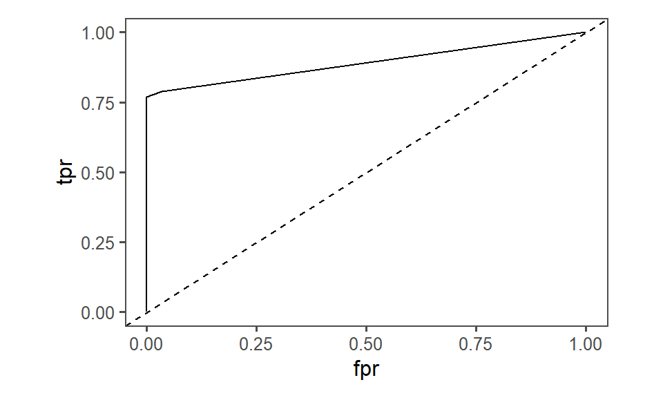

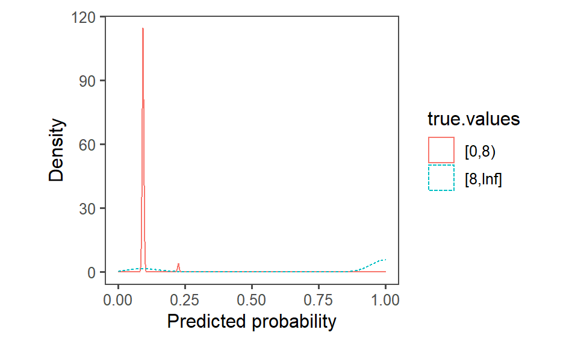

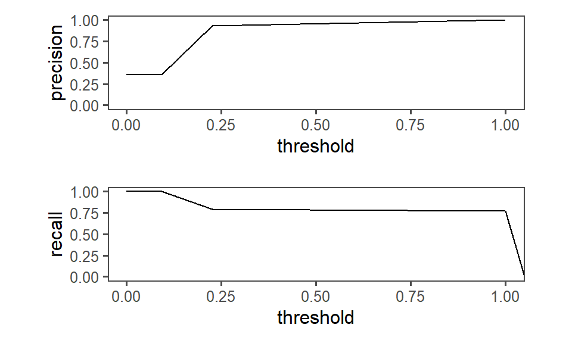

```
## Confusion Matrix       true.values
## pred    [0,8) [8,Inf]
##   FALSE 19587    2552
##   TRUE      0    8454
## [1] "Model Log Likelihood: -7871.04198608475"
## [1] "Null Model Log Likelihood: -19985.7151402402"
```

```
##                          model.type             model.name train.auc   cal.auc
## decision.tree.all.vars multivariate decision.tree.all.vars 0.9620277 0.8907348
```

```r
fV <- paste(outcome,' ~ ', paste(c(catvars,numvars), collapse=' + '), sep='')

decision.tree.all.vars <- rpart(fV, data=dTrain)

evaluate_and_log_model(model.type = 'multivariate',
                       model.name = 'decision.tree.all.vars',
                       predictions.train = predict(decision.tree.all.vars,newdata=dTrain)[,pos.label],
                       true.values.train = dTrain[,outcome],
                       predictions.cal = predict(decision.tree.all.vars, newdata=dCal)[,pos.label],
                       true.values.cal = dCal[,outcome])
```

#### Decision tree with the selected variables.

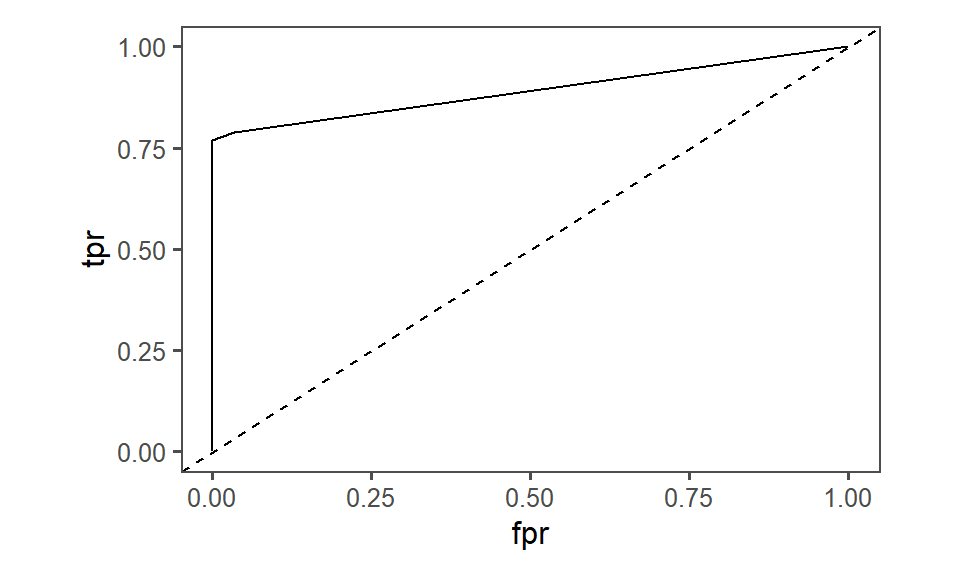

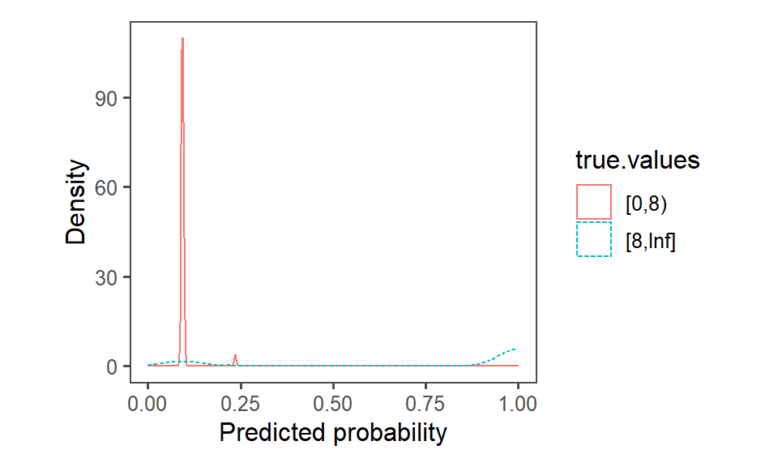

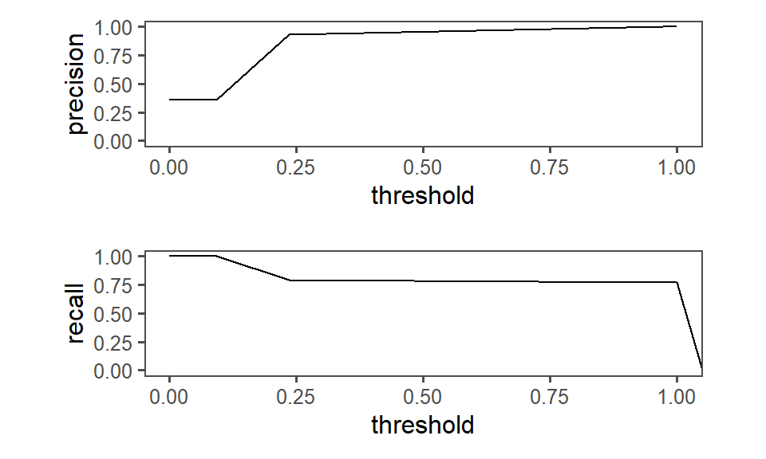

```
## Confusion Matrix       true.values
## pred    [0,8) [8,Inf]
##   FALSE 19587    2550
##   TRUE      0    8456
## [1] "Model Log Likelihood: -7866.74375261547"
## [1] "Null Model Log Likelihood: -19985.7151402402"
```

```
##                          model.type             model.name train.auc   cal.auc
## decision.tree.sel.vars multivariate decision.tree.sel.vars 0.9620255 0.8907379
```

```r
fV <- paste(outcome,' ~ ',  paste(selVars, collapse=' + '), sep='')

decision.tree.sel.vars <- rpart(fV, data=dTrain)

evaluate_and_log_model(model.type = 'multivariate',
                       model.name = 'decision.tree.sel.vars',
                       predictions.train = predict(decision.tree.sel.vars, newdata=dTrain)[,pos.label],
                       true.values.train = dTrain[,outcome],
                       predictions.cal = predict(decision.tree.sel.vars, newdata=dCal)[,pos.label],
                       true.values.cal = dCal[,outcome])
```

The model of “decision tree with selected variables” has log likelihood value of -7866.744, which is better than the Null model of -19985.715. The training set has an AUC of 0.962 and a value of 0.891 for the calibration set.

We can see that the train.auc and cal.auc are both very close to the result when we use the all variables to construct the decision tree. It may because we have very enough data(totally 160248 in training set and 30593 in calibration set). So although some variables are not proper to be selected, they can be gradually given lower weight in many hierarchies of subtrees.

Also, we can see that the train.auc is larger than the cal.auc, so it may because the model has the overfitted problem. We can still improve it by Changing some parameters or using other models.

### Logistic Regression

Logistic Regression model with selected variables

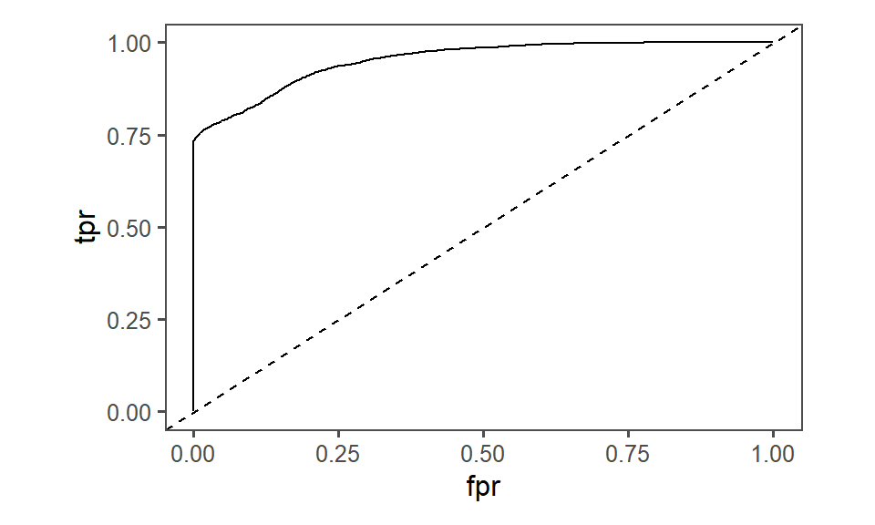

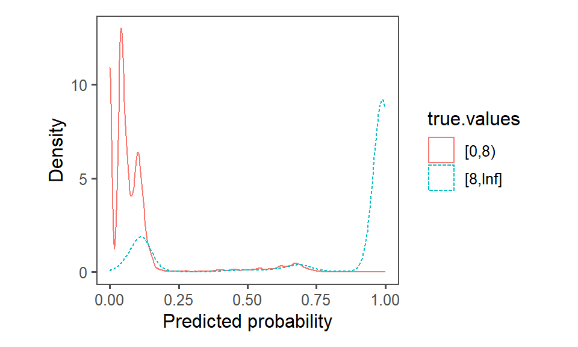

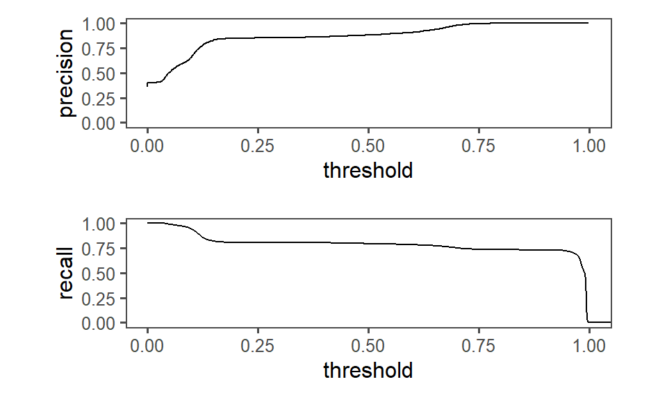

```
## Confusion Matrix       true.values
## pred    [0,8) [8,Inf]
##   FALSE 18407    2258
##   TRUE   1180    8748
## [1] "Model Log Likelihood: -7841.86413490205"
## [1] "Null Model Log Likelihood: -19985.7151402402"
```

```
##                        model.type           model.name train.auc   cal.auc
## logreg.sel.pred.vars multivariate logreg.sel.pred.vars 0.9783073 0.9520241
```

```r
fV <- paste(outcome,' ~ ',  paste(selPredVars, collapse=' + '), sep='')

logreg.sel.pred.vars <- glm(fV, data=dTrain, family = binomial)

evaluate_and_log_model(model.type = 'multivariate',
                       model.name = 'logreg.sel.pred.vars',
                       predictions.train = predict(logreg.sel.pred.vars, newdata=dTrain, type = 'response'),
                       true.values.train = dTrain[,outcome],
                       predictions.cal = predict(logreg.sel.pred.vars, newdata=dCal, type = 'response'),
                       true.values.cal = dCal[,outcome])
```

### XGBOOST

XGBoost allows the use of linear classifiers in addition to regression trees and, in terms of the objective function, XGBoost’s objective function incorporates a canonical term that contains the number of leaf nodes and the L2 parametrization of the leaf scores to avoid overfitting and improve the generalisation of the model by controlling the complexity of the tree model.

```r
tplan <- vtreat::designTreatmentsZ(dTrain, cand.columns, minFraction= 0.025, verbose=FALSE)

sf <- tplan$scoreFrame
newvars <- sf$varName[sf$code %in% c("lev", "clean", "isBAD")]

trainVtreat <- as.matrix(vtreat::prepare(tplan, dTrain, varRestriction = newvars))
calVtreat <- as.matrix(vtreat::prepare(tplan, dCal, varRestriction = newvars))
testVtreat <- as.matrix(vtreat::prepare(tplan, dTest, varRestriction = newvars))

dim(trainVtreat)
```

```
## [1] 160248    122
```

```r
set.seed(0)

cv <- xgb.cv(data= trainVtreat,label= dTrain[,outcome]==pos.label,params=list(objective="binary:logistic"),
 verbose= FALSE,early_stopping_rounds = 20,nfold= 3,
 nrounds=100,
 print_every_n=10,
 metrics="logloss")

nrounds  <- which.min(cv$evaluation_log$test_error_mean)

xgbtmodel <- xgboost(data= trainVtreat,label= dTrain[,outcome]==pos.label,params=list(objective="binary:logistic"),
 verbose= FALSE,early_stopping_rounds = 20,nfold= 3,
 nrounds=100,
 print_every_n=10,
 metrics="logloss")
```

[output not shown]

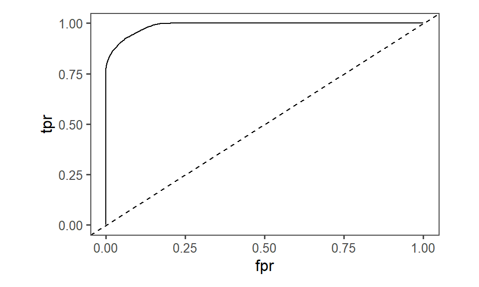

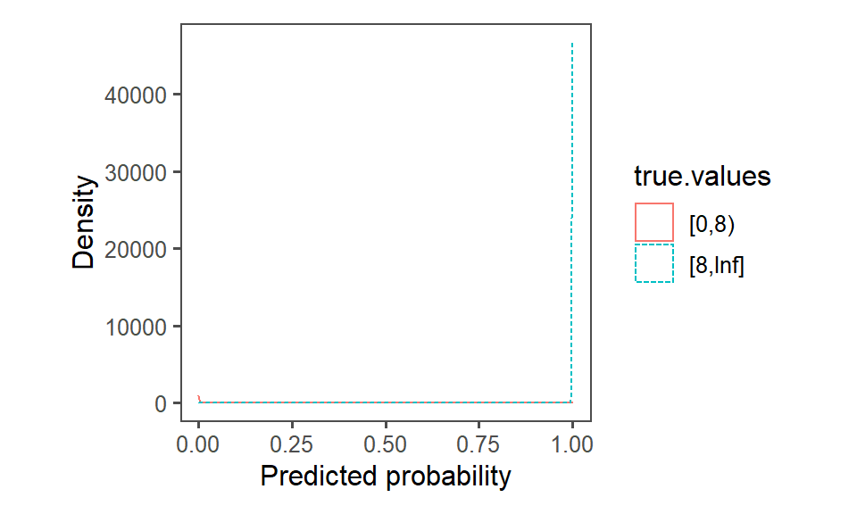

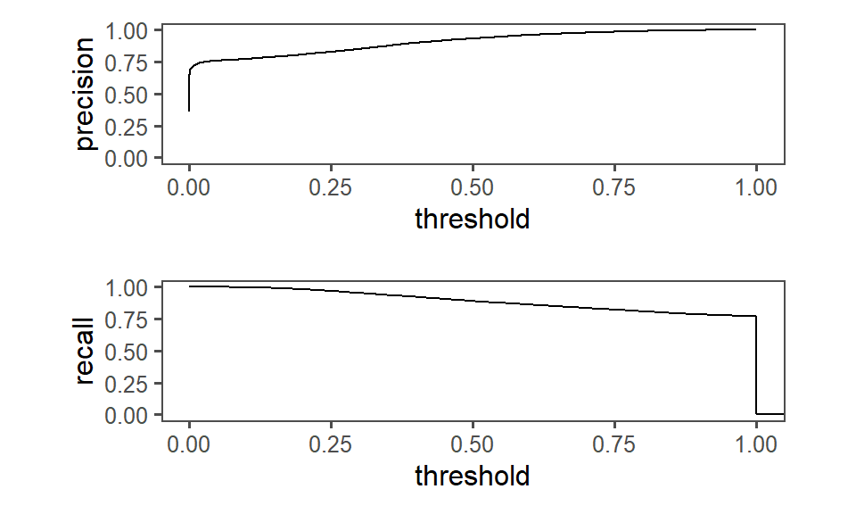

```
## Confusion Matrix       true.values
## pred    [0,8) [8,Inf]
##   FALSE 18871    1227
##   TRUE    716    9779
## [1] "Model Log Likelihood: -3700.31981464004"
## [1] "Null Model Log Likelihood: -19985.7151402402"
```

```
##             model.type model.name train.auc   cal.auc
## xgbtmodel multivariate  xgbtmodel 0.9983978 0.9884168
```

```r
evaluate_and_log_model(model.type = 'multivariate',
                       model.name = 'xgbtmodel',
                       predictions.train = predict(xgbtmodel,trainVtreat),
                       true.values.train = dTrain[,outcome],
                       predictions.cal = predict(xgbtmodel,calVtreat),
                       true.values.cal = dCal[,outcome])
```

The model of XGBOOST assign an amazing log likelihood value of -3700.320, which is much better than the model of decision trees and the model of logistic regression. The training set and the calibration set have amazing auc 0.998 and 0.988 out of a total of 190,841 data! The ROC curve for this model has shown improvement compared to the two previous models. The precision has shown improvement for the model and there is improvement with the recall.

### Compare all models

Top 10 models

```r
kable(head(models.auc[order(models.auc$cal.auc, decreasing = T), ], 10))
```

|  | model.type | model.name | train.auc | cal.auc |
| --- | --- | --- | --- | --- |
| xgbtmodel | multivariate | xgbtmodel | 0.9983978 | 0.9884168 |
| logreg.sel.pred.vars | multivariate | logreg.sel.pred.vars | 0.9783073 | 0.9520241 |
| DAYS_LOST | univariate | DAYS_LOST | 0.9241345 | 0.8937003 |
| decision.tree.sel.vars | multivariate | decision.tree.sel.vars | 0.9620255 | 0.8907379 |
| decision.tree.all.vars | multivariate | decision.tree.all.vars | 0.9620277 | 0.8907348 |
| DEGREE_INJURY | univariate | DEGREE_INJURY | 0.7508199 | 0.8818884 |
| NATURE_INJURY | univariate | NATURE_INJURY | 0.7283197 | 0.7790178 |
| INJ_BODY_PART | univariate | INJ_BODY_PART | 0.7199998 | 0.7666708 |
| ACCIDENT_TYPE | univariate | ACCIDENT_TYPE | 0.7092263 | 0.7332957 |
| INJURY_SOURCE | univariate | INJURY_SOURCE | 0.6974993 | 0.7181528 |

Comparing all the evaluation data from all the models, we can see that the XGBOOST model outperforms the other models on all measures. Also, we find that the DAY_LOST and DEGREE_INJURY are much better in all single variable models and very close to two decision tree models. It may because the decision tree models mainly depend on these two variables to make decisions. However, the decision tree model can’t combine these two important variables with each others very well. Therefore, we can see that XGBOOST and logistic regression perform much better than decision tree because they can give each of these two important variables enough weight and add up with them.

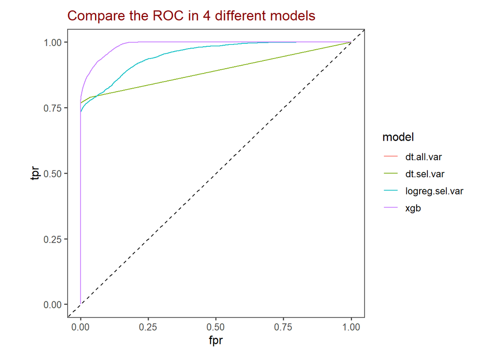

```r
xgb.pred <- prediction(predict(xgbtmodel,calVtreat), dCal[,outcome])
logreg.sel.var.pred <- prediction(predict(logreg.sel.pred.vars, newdata=dCal, type = 'response') , dCal[,outcome])
dt.sel.var.pred <- prediction(predict(decision.tree.sel.vars, newdata=dCal)[,pos.label] , dCal[,outcome])
dt.all.var.pred <- prediction(predict(decision.tree.all.vars, newdata=dCal)[,pos.label], dCal[,outcome])

preds <- list(xgb.pred, logreg.sel.var.pred, dt.sel.var.pred, dt.all.var.pred)
model.names <- c('xgb', 'logreg.sel.var', 'dt.sel.var', 'dt.all.var')
roc.df <- data.frame()
for(i in 1:length(model.names)){
  pred <- preds[[i]]
  model.name <- model.names[i]
  perf <- performance( pred, "tpr", "fpr" )
  roc.df <- rbind(roc.df, data.frame(
               'fpr'=unlist(perf@x.values),
               'tpr'=unlist(perf@y.values),
               'threshold'=unlist(perf@alpha.values),
               'model'=model.name))
}

ggplot(roc.df, aes(x=fpr, y=tpr, group=model, color=model))+
  geom_line() +
  geom_abline(intercept = 0, slope = 1, linetype='dashed') +
  ggtitle("Compare the ROC in 4 different models") +
  project_theme
```

easily to see that our best model is the XGBOOST.

### Evaluate selected model on the test set

Use the XGBOOST model to test the data to see how it is performing.

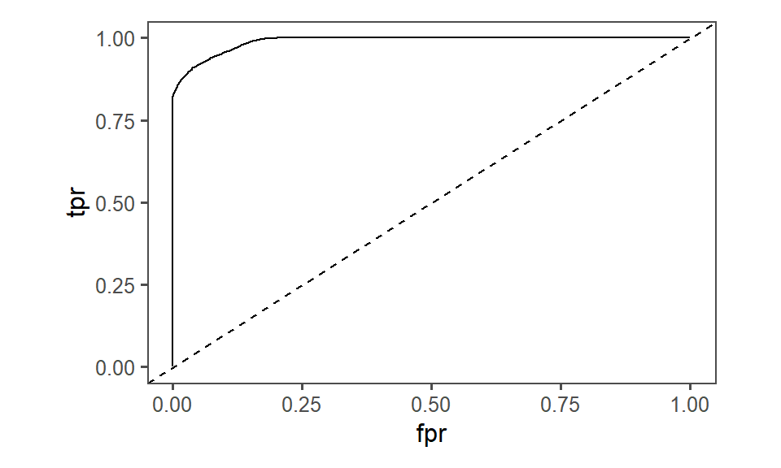

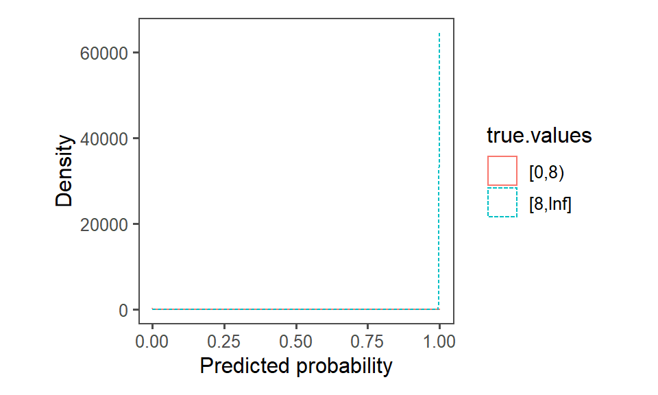

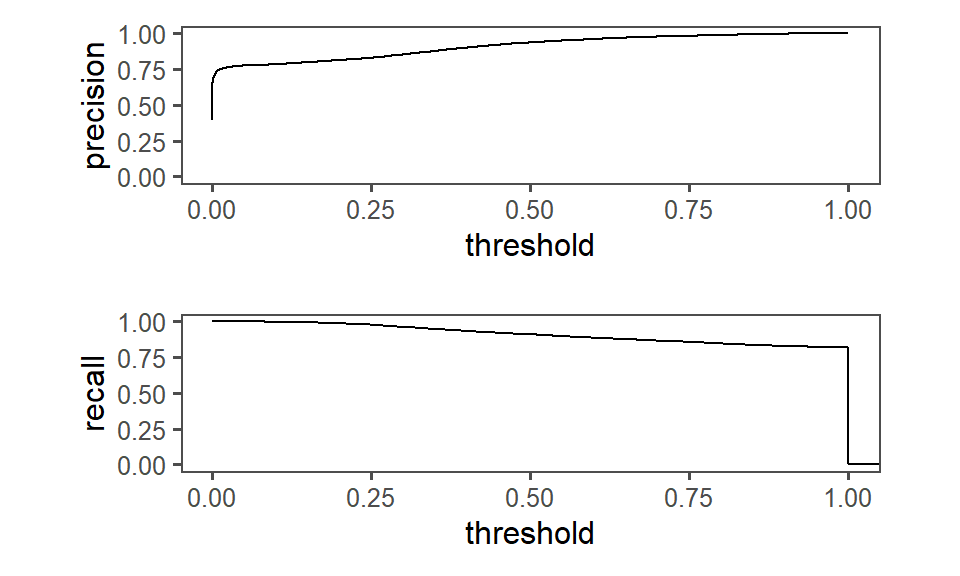

```
## Confusion Matrix       true.values
## pred    [0,8) [8,Inf]
##   FALSE  6947     427
##   TRUE    292    4307
## [1] "Model Log Likelihood: -1398.02250558279"
## [1] "Null Model Log Likelihood: -8035.05613403374"
```

```
## [1] 0.9893667
```

```r
evaluate_performance(predict(xgbtmodel,testVtreat), dTest[,outcome],
                     do.print=TRUE, threshold.value=0.5, pos=pos.label)
```

The log likelihood of the “XGBOOST” model is -1398.023, which is much better than the null model’s -8035.056. The presion and recall rate look very great. For the prediction quality plot, the model is a significant improvement over the previous one, but the two distributions have been clearly separated (as shown in the figure above). This suggests that the model has built a classifier that achieves both good recall and accuracy.

## Conclusion

1.This section we define a new column DAY_AFFECT, which means the total number of working days affected by all injured personnel. And we use 8 as boundary value to define an accident as unaffected accident and affected accident, and then select some variables and choose some model to finish the classification task.

2.In terms of model selection, we use the single variable model, decision tree, logistic regression and XGBOOST. The decision tree is generated from the data. It is a prediction tree based on classification and training, starting from the root node and progressively subdivided according to its test attributes towards its children in turn, allowing prediction and classification of the future based on known information. Logistic regression can be represented as: finding the best-fit parameters for the non-linear function SIGMOID, done by an optimisation algorithm, and can be seen as a perceptron problem. xGBoost in addition to regression trees, linear classifiers can also be used, and in terms of the objective function, XGBoost’s objective function incorporates a regular term to avoid overfitting and improve the generalisation of the model by controlling the complexity of the tree model, which make XGBoost show significant advantages in computational efficiency and prediction results.

# Part2 Clustering

## Overview

We found in Project 1 that the occurrence of accidents is closely related to time, we grouped the US Accident Injury Dataset according to the time of the accident. So we grouped the US Accident Injury Dataset according to the time of the accident and then hoped to group the new sample group by applying a clustering algorithm to these variables to design new indicators.

## Data preparation

### Generate a new table

Before generating a new table, we need to clean the data, such as filtering out time greater than 2400 (because there are never more than 24 hours in a day) and replacing NA value with the mean (because the number of NA values represent only about 10%).

```r
# Group and filter the data
us_data2 <- read.csv("us_data_full.csv")
data_cluster <- us_data2 %>%
  group_by(CAL_YR, CAL_QTR) %>%
  filter(SHIFT_BEGIN_TIME <= 2400) %>%
  filter(!(CAL_YR == 2015 && CAL_QTR == 2))

# Replace some missing values with mean
mean_shiftbegintime <- mean(data_cluster$SHIFT_BEGIN_TIME, na.rm=T)
mean_noinjuries <- mean(data_cluster$NO_INJURIES, na.rm=T)
mean_TOT <- mean(data_cluster$TOT_EXPER, na.rm=T)
mean_MINE <- mean(data_cluster$MINE_EXPER, na.rm=T)
mean_JOB <- mean(data_cluster$JOB_EXPER, na.rm=T)
data_cluster$SHIFT_BEGIN_TIME = replace(data_cluster$SHIFT_BEGIN_TIME, is.na(data_cluster$TOT_EXPER), mean_shiftbegintime)
data_cluster$NO_INJURIES = replace(data_cluster$NO_INJURIES, is.na(data_cluster$MINE_EXPER), mean_noinjuries)
data_cluster$TOT_EXPER = replace(data_cluster$TOT_EXPER, is.na(data_cluster$TOT_EXPER), mean_TOT)
data_cluster$MINE_EXPER = replace(data_cluster$MINE_EXPER, is.na(data_cluster$MINE_EXPER), mean_MINE)
data_cluster$JOB_EXPER = replace(data_cluster$JOB_EXPER, is.na(data_cluster$JOB_EXPER), mean_JOB)

# Generate and show the new table
data_cluster <- data_cluster %>%
  summarise(ACCIDENT_NUM = n(), M_SHIFT_BEGIN_TIME = mean(SHIFT_BEGIN_TIME),
            M_NO_INJURIES = mean(NO_INJURIES), M_TOT_EXPER = mean(TOT_EXPER),
            M_MINE_EXPER = mean(MINE_EXPER), M_JOB_EXPER = mean(JOB_EXPER))
data_cluster
```

```
## # A tibble: 61 × 8
## # Groups:   CAL_YR [16]
##    CAL_YR CAL_QTR ACCIDENT_NUM M_SHIFT_BEGIN_T…¹ M_NO_…² M_TOT…³ M_MIN…⁴ M_JOB…⁵
##     <int>   <int>        <int>             <dbl>   <dbl>   <dbl>   <dbl>   <dbl>
##  1   2000       1         4345             1025.   1.00     12.2    7.54    7.28
##  2   2000       2         4504             1027.   0.990    12.2    7.28    7.17
##  3   2000       3         4736             1033.   1.01     12.1    7.01    7.08
##  4   2000       4         3830             1031.   0.991    12.0    7.19    6.90
##  5   2001       1         3987             1024.   1.01     12.7    7.98    7.37
##  6   2001       2         4017             1035.   0.995    11.7    6.90    6.88
##  7   2001       3         4688             1043.   1.04     11.4    6.73    6.74
##  8   2001       4         3688             1046.   0.991    11.6    6.73    6.88
##  9   2002       1         3837             1043.   0.991    12.1    7.14    7.10
## 10   2002       2         3839             1032.   0.989    11.8    6.83    7.11
## # … with 51 more rows, and abbreviated variable names ¹M_SHIFT_BEGIN_TIME,
## #   ²M_NO_INJURIES, ³M_TOT_EXPER, ⁴M_MINE_EXPER, ⁵M_JOB_EXPER
## # ℹ Use `print(n = ...)` to see more rows
```

### Check the new data

Perform some necessary data checks i.e. descriptive statistics on the data such as mean, standard deviation and so on.

```r
desc_stats = data.frame( Min=apply(data_cluster, 2, min),#minimum
                          Med=apply(data_cluster, 2, median),#median
                          Mean=apply(data_cluster, 2, mean),#mean
                          SD=apply(data_cluster, 2, sd),#Standard deviation
                          Max=apply(data_cluster, 2, max)#maximum
)
desc_stats = round(desc_stats, 1)# Retain one decimal place
desc_stats
```

```
##                       Min    Med   Mean    SD    Max
## CAL_YR             2000.0 2007.0 2007.1   4.4 2015.0
## CAL_QTR               1.0    2.0    2.5   1.1    4.0
## ACCIDENT_NUM       1974.0 3189.0 3171.2 681.0 4736.0
## M_SHIFT_BEGIN_TIME 1002.6 1032.9 1034.6  15.8 1076.0
## M_NO_INJURIES         1.0    1.0    1.0   0.1    1.4
## M_TOT_EXPER           9.7   11.0   11.1   0.8   12.7
## M_MINE_EXPER          5.7    6.4    6.5   0.5    8.0
## M_JOB_EXPER           6.3    6.9    6.9   0.3    7.6
```

### Scaling the data

Make clustering more coordinate-free

```r
vars.to.use <- colnames(data_cluster)[-1]
scaled_df <- scale(data_cluster[,vars.to.use])
(attr(scaled_df, "scaled:center"))
```

```
##            CAL_QTR       ACCIDENT_NUM M_SHIFT_BEGIN_TIME      M_NO_INJURIES
##           2.475410        3171.213115        1034.567008           1.009412
##        M_TOT_EXPER       M_MINE_EXPER        M_JOB_EXPER
##          11.102737           6.486616           6.898443
```

```r
(attr(scaled_df, "scaled:scale"))
```

```
##            CAL_QTR       ACCIDENT_NUM M_SHIFT_BEGIN_TIME      M_NO_INJURIES
##         1.13440965       681.02574877        15.80627554         0.05291098
##        M_TOT_EXPER       M_MINE_EXPER        M_JOB_EXPER
##         0.76068893         0.53845813         0.33395750
```

## Consturct the model

### Finding the number of clusters k

#### Plot the CH index vs k

We can choose the CH metric to find the k-value, which measures the tightness within a class by calculating the sum of the squares of the distances between the points in the class and the class centre, and the separation of the data set by calculating the sum of the squares of the distances between the centroids of each class and the centroids of the data set, with the CH metric being obtained from the ratio of separation to tightness. Thereby, a larger CH represents a tighter class itself and a more dispersed class to class, i.e. a better clustering result.

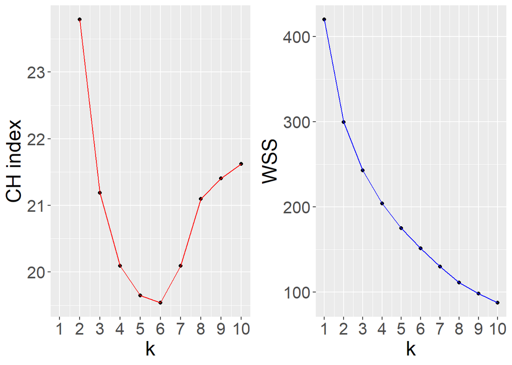

```r
# Calculate Euclidean distance
sqr_euDist <- function(x, y) {
  sum((x - y)^2)
}

# Calculate the WSS of the cluster
wss <- function(clustermat) {
  c0 <- colMeans(clustermat)
  sum(apply( clustermat, 1, FUN=function(row) {sqr_euDist(row, c0)} ))
}
wss_total <- function(scaled_df, labels) {
  wss.sum <- 0
  k <- length(unique(labels))
  for (i in 1:k)
    wss.sum <- wss.sum + wss(subset(scaled_df, labels == i))
  wss.sum
}

# Calculate the total sum of squares (rss) distance of data points about the global mean
tss <- function(scaled_df) {
  wss(scaled_df)
}

# Calculate the CH index using hierarchical clustering or k-mean clustering
CH_index <- function(scaled_df, kmax, method="kmeans") {
  if (!(method %in% c("kmeans", "hclust")))
    stop("method must be one of c('kmeans', 'hclust')")
  npts <- nrow(scaled_df)
  wss.value <- numeric(kmax) # create a vector of numeric type

  wss.value[1] <- wss(scaled_df)
  if (method == "kmeans") {
    # kmeans
    for (k in 2:kmax) {
      clustering <- kmeans(scaled_df, k, nstart=10, iter.max=100)
    wss.value[k] <- clustering$tot.withinss
    }
  } else {
    # hclust
    d <- dist(scaled_df, method="euclidean")
    pfit <- hclust(d, method="ward.D2")
    for (k in 2:kmax) {
      labels <- cutree(pfit, k=k)
      wss.value[k] <- wss_total(scaled_df, labels)
    }
  }
  bss.value <- tss(scaled_df) - wss.value # this is a vector
  B <- bss.value / (0:(kmax-1)) # also a vector
  W <- wss.value / (npts - 1:kmax) # also a vector
  data.frame(k = 1:kmax, CH_index = B/W, WSS = wss.value)
}

# Using a line graph to clearly show the CH values
crit.df <- CH_index(scaled_df, 10, method="hclust")

fig1 <- ggplot(crit.df, aes(x=k, y=CH_index)) +
  geom_point() + geom_line(colour="red") +
  scale_x_continuous(breaks=1:10, labels=1:10) +
  labs(y="CH index") + theme(text=element_text(size=20))

fig2 <- ggplot(crit.df, aes(x=k, y=WSS), color="blue") +
  geom_point() + geom_line(colour="blue") +
  scale_x_continuous(breaks=1:10, labels=1:10) +
  theme(text=element_text(size=20))

grid.arrange(fig1, fig2, nrow=1)
```

#### Show the cluster plot

So we now divide the sample into two and six clusters respectively and analyse which is more appropriate.

1.kmeans clustering by 2 groups

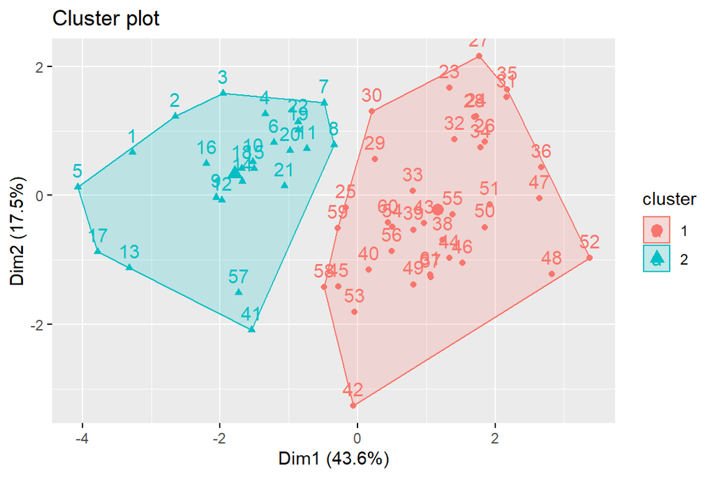

```r
km.res = kmeans(scaled_df, 2)
fviz_cluster(km.res, scaled_df)
```

2.kmeans clustering by 6 groups

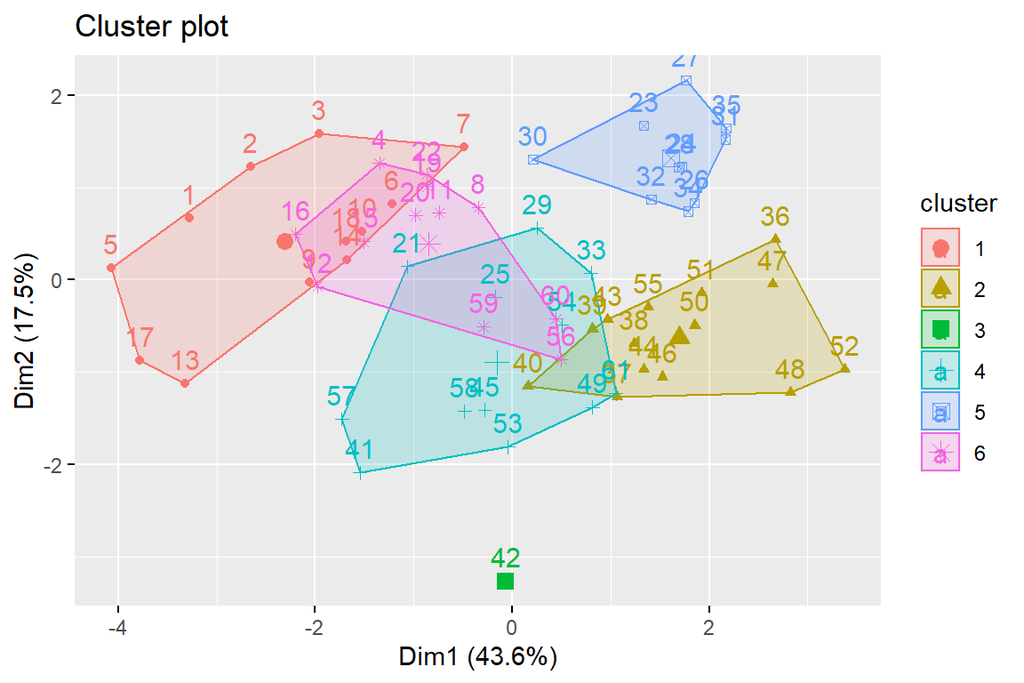

```r
km.res = kmeans(scaled_df, 6)
fviz_cluster(km.res, scaled_df)
```

We can see that when k = 2, two clusters are well separated. However when k = 6, many clusters overlap with each others.

#### Show the cluster dendrogram

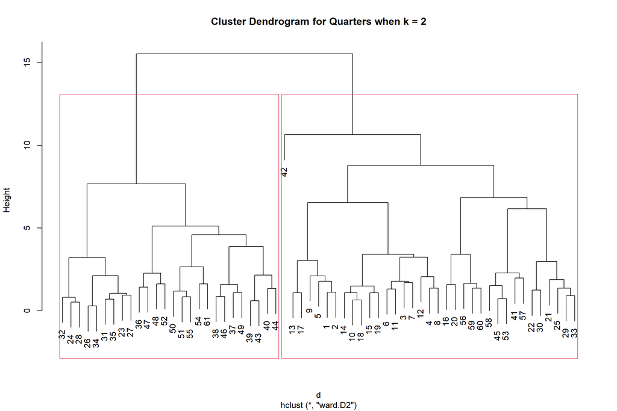

```r
d <- dist(scaled_df, method="euclidean")
hfit <- hclust(d, method = 'ward.D2')
plot(hfit, main="Cluster Dendrogram for Quarters when k = 2")
rect.hclust(hfit, k=2)
```

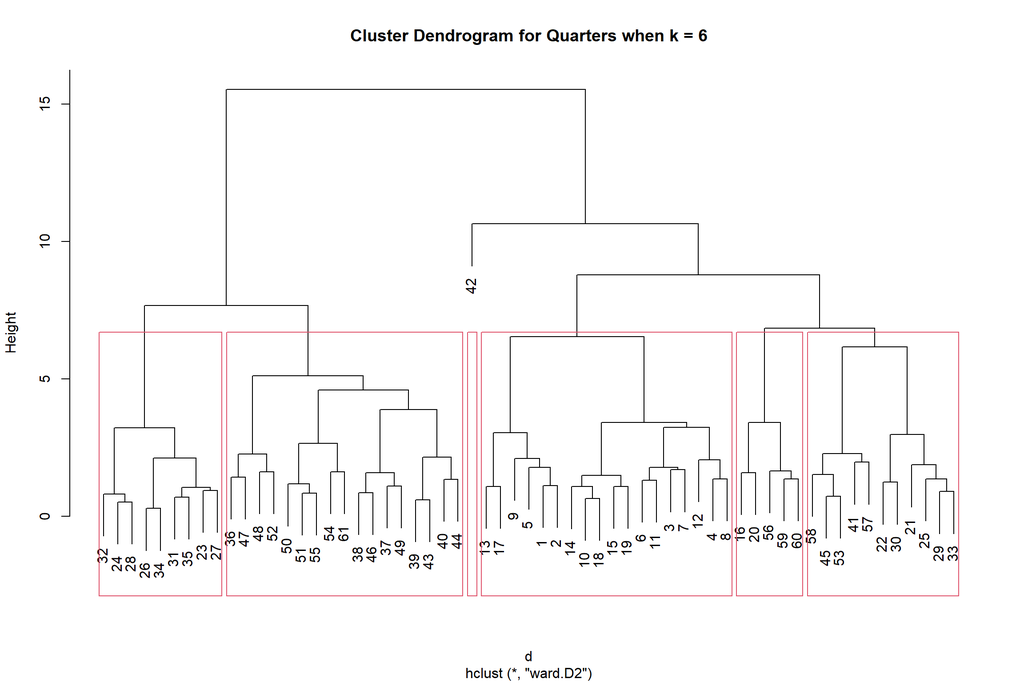

```r
d <- dist(scaled_df, method="euclidean")
hfit <- hclust(d, method = 'ward.D2')
plot(hfit, main="Cluster Dendrogram for Quarters when k = 6")
rect.hclust(hfit, k=6)
```

Finally, we can draw a conclusion that the optimum number of clusters K should be 2. There are three reasons: – 1. From the plot of CH index vs k, the CH index is maximised at k = 2 not k = 6, which means when k = 2 a tighter cluster itself and a more dispersed cluster to cluster. – 2. From the cluster plot, when k = 2, two clusters are well separated. However when k = 6, many clusters overlap with each others. – 3. From the cluster dendrogram, When k=2, it is significantly more stable, and when k=6, one of the clusters even has only one data

### Extract members of each cluster and kMeans Clustering

At this stage, we will use the k-means algorithm to cluster the sample set and find the criteria for Cluster 1 and Cluster 2 based on the characteristics of each cluster after clustering. Also, at this stage we use cosine similarity to determine the space vector and choose the Euclidean distance to evaluate the distance between two sample points

```r
groups <- cutree(hfit, k=2)
groups
```

```
##  [1] 1 1 1 1 1 1 1 1 1 1 1 1 1 1 1 1 1 1 1 1 1 1 2 2 1 2 2 2 1 1 2 2 1 2 2 2 2 2
## [39] 2 2 1 1 2 2 1 2 2 2 2 2 2 2 1 2 2 1 1 1 1 1 2
```

```r
print_clusters <- function(df, groups, cols_to_print) {
  Ngroups <- max(groups)
  for (i in 1:Ngroups) {
    print(paste("cluster", i))
    print(df[groups == i, cols_to_print])
  }
}

cols_to_print <- c("CAL_YR","CAL_QTR","ACCIDENT_NUM","M_SHIFT_BEGIN_TIME","M_NO_INJURIES","M_TOT_EXPER","M_MINE_EXPER","M_JOB_EXPER")
print_clusters(data_cluster, groups, cols_to_print)
```

```
## [1] "cluster 1"
## # A tibble: 35 × 8
## # Groups:   CAL_YR [13]
##    CAL_YR CAL_QTR ACCIDENT_NUM M_SHIFT_BEGIN_T…¹ M_NO_…² M_TOT…³ M_MIN…⁴ M_JOB…⁵
##     <int>   <int>        <int>             <dbl>   <dbl>   <dbl>   <dbl>   <dbl>
##  1   2000       1         4345             1025.   1.00     12.2    7.54    7.28
##  2   2000       2         4504             1027.   0.990    12.2    7.28    7.17
##  3   2000       3         4736             1033.   1.01     12.1    7.01    7.08
##  4   2000       4         3830             1031.   0.991    12.0    7.19    6.90
##  5   2001       1         3987             1024.   1.01     12.7    7.98    7.37
##  6   2001       2         4017             1035.   0.995    11.7    6.90    6.88
##  7   2001       3         4688             1043.   1.04     11.4    6.73    6.74
##  8   2001       4         3688             1046.   0.991    11.6    6.73    6.88
##  9   2002       1         3837             1043.   0.991    12.1    7.14    7.10
## 10   2002       2         3839             1032.   0.989    11.8    6.83    7.11
## # … with 25 more rows, and abbreviated variable names ¹M_SHIFT_BEGIN_TIME,
## #   ²M_NO_INJURIES, ³M_TOT_EXPER, ⁴M_MINE_EXPER, ⁵M_JOB_EXPER
## # ℹ Use `print(n = ...)` to see more rows
## [1] "cluster 2"
## # A tibble: 26 × 8
## # Groups:   CAL_YR [10]
##    CAL_YR CAL_QTR ACCIDENT_NUM M_SHIFT_BEGIN_T…¹ M_NO_…² M_TOT…³ M_MIN…⁴ M_JOB…⁵
##     <int>   <int>        <int>             <dbl>   <dbl>   <dbl>   <dbl>   <dbl>
##  1   2005       3         3956             1028.   0.995    10.4    6.00    6.50
##  2   2005       4         3248             1026.   1.01     10.5    6.10    6.40
##  3   2006       2         3529             1039.   1.00     10.4    5.84    6.35
##  4   2006       3         3962             1017.   0.991    10.2    5.85    6.32
##  5   2006       4         3189             1025.   0.993    10.4    6.08    6.50
##  6   2007       3         3855             1031.   1.02     10.0    5.77    6.34
##  7   2007       4         3087             1029.   0.991    10.5    6.11    6.64
##  8   2008       2         3451             1037.   0.997    10.3    5.87    6.42
##  9   2008       3         3664             1027.   0.992    10.3    5.66    6.30
## 10   2008       4         2898             1047.   1.01     10.0    5.99    6.34
## # … with 16 more rows, and abbreviated variable names ¹M_SHIFT_BEGIN_TIME,
## #   ²M_NO_INJURIES, ³M_TOT_EXPER, ⁴M_MINE_EXPER, ⁵M_JOB_EXPER
## # ℹ Use `print(n = ...)` to see more rows
```

```r
set.seed(1000)
(km_result <- kmeans(scaled_df, 2))
```

```
## K-means clustering with 2 clusters of sizes 37, 24
##
## Cluster means:
##      CAL_QTR ACCIDENT_NUM M_SHIFT_BEGIN_TIME M_NO_INJURIES M_TOT_EXPER
## 1  0.1050632   -0.4249109          0.2519584     0.1379554  -0.6727497
## 2 -0.1619725    0.6550710         -0.3884359    -0.2126812   1.0371557
##   M_MINE_EXPER M_JOB_EXPER
## 1    -0.656125  -0.5027517
## 2     1.011526   0.7750755
##
## Clustering vector:
##  [1] 2 2 2 2 2 2 2 2 2 2 2 2 2 2 2 2 2 2 2 2 2 2 1 1 1 1 1 1 1 1 1 1 1 1 1 1 1 1
## [39] 1 1 2 1 1 1 1 1 1 1 1 1 1 1 1 1 1 1 2 1 1 1 1
##
## Within cluster sum of squares by cluster:
## [1] 199.95896  87.44664
##  (between_SS / total_SS =  31.6 %)
##
## Available components:
##
## [1] "cluster"      "centers"      "totss"        "withinss"     "tot.withinss"
## [6] "betweenss"    "size"         "iter"         "ifault"
```

```r
data_result_cluster <- cbind(data_cluster, cluster = km_result$cluster)
head(data_result_cluster)
```

```
## # A tibble: 6 × 9
## # Groups:   CAL_YR [2]
##   CAL_YR CAL_QTR ACCIDENT_NUM M_SHIFT_…¹ M_NO_…² M_TOT…³ M_MIN…⁴ M_JOB…⁵ cluster
##    <int>   <int>        <int>      <dbl>   <dbl>   <dbl>   <dbl>   <dbl>   <int>
## 1   2000       1         4345      1025.   1.00     12.2    7.54    7.28       2
## 2   2000       2         4504      1027.   0.990    12.2    7.28    7.17       2
## 3   2000       3         4736      1033.   1.01     12.1    7.01    7.08       2
## 4   2000       4         3830      1031.   0.991    12.0    7.19    6.90       2
## 5   2001       1         3987      1024.   1.01     12.7    7.98    7.37       2
## 6   2001       2         4017      1035.   0.995    11.7    6.90    6.88       2
## # … with abbreviated variable names ¹M_SHIFT_BEGIN_TIME, ²M_NO_INJURIES,
## #   ³M_TOT_EXPER, ⁴M_MINE_EXPER, ⁵M_JOB_EXPER
```

```r
(clusters <- table(data_result_cluster$cluster))
```

```
##
##  1  2
## 37 24
```

```r
kable(table(clusters))
```

| clusters | Freq |
| --- | --- |
| 24 | 1 |
| 37 | 1 |

```r
kbest.p <- 2
kmClusters <- kmeans(scaled_df, kbest.p, nstart=100, iter.max=100)
kmClusters$centers
```

```
##      CAL_QTR ACCIDENT_NUM M_SHIFT_BEGIN_TIME M_NO_INJURIES M_TOT_EXPER
## 1  0.1050632   -0.4249109          0.2519584     0.1379554  -0.6727497
## 2 -0.1619725    0.6550710         -0.3884359    -0.2126812   1.0371557
##   M_MINE_EXPER M_JOB_EXPER
## 1    -0.656125  -0.5027517
## 2     1.011526   0.7750755
```

```r
kmClusters$size
```

```
## [1] 37 24
```

Cluster 1 mainly contains the number of accidents from 2005, with a lower number of accidents, later shift begin time and less work experience.

Cluster 2 mainly contains the number of accidents from 2000, with a larger number of accidents, earlier shift begin time and more work experience.

```r
kbest.p <- 2
cboot.hclust <- clusterboot(scaled_df, clustermethod=hclustCBI,method="ward.D2", k=kbest.p)
```

[output not shown]

[output cut: 45 more lines]

[output not shown]

```r
summary(cboot.hclust$result)
```

```
##               Length Class  Mode
## result         7     hclust list
## noise          1     -none- logical
## nc             1     -none- numeric
## clusterlist    2     -none- list
## partition     61     -none- numeric
## clustermethod  1     -none- character
## nccl           1     -none- numeric
```

```r
1 - cboot.hclust$bootbrd/100
```

```
## [1] 0.92 0.99
```

So the both the cluster 1 and cluster 2 are very stable.

### Clustering visualisation study

Visualize the clustering data

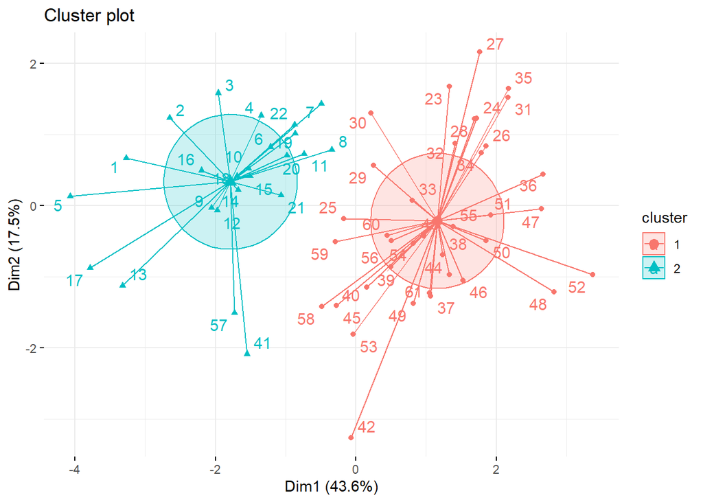

```r
fviz_cluster(km_result, data = scaled_df,ellipse.type = "euclid",star.plot = TRUE, repel = TRUE,ggtheme = theme_minimal())
```

Afterwards we will visualise the sample set that has been clustered and study the two principal component dimensions obtained through the CPCA method of principal component analysis. The visualisation shows that groups with similar accident times as well as a similar number of accidents can be well clustered together, which can reflect the fact that accidents occur at different times and the factors they contain are similar.

If we divide the sample into 6 clusters

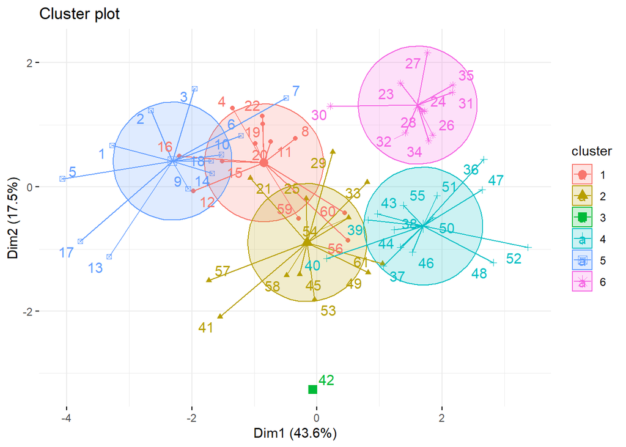

```r
km_result_6 <- kmeans(scaled_df, 6)
fviz_cluster(km_result_6, data = scaled_df,ellipse.type = "euclid",star.plot = TRUE, repel = TRUE,ggtheme = theme_minimal())
```

As the figure above, k = 6 is too large for the sample set, resulting in a small number of samples in each cluster and an overfitting situation.

### Show the cluster results

Now we show the cluster result by showing the clustering dendrogram. Hierarchical clustering using Euclidean distances was first used to find pairwise similarities between samples, and then the least variance method was used to generate a hierarchical ward least variance method.

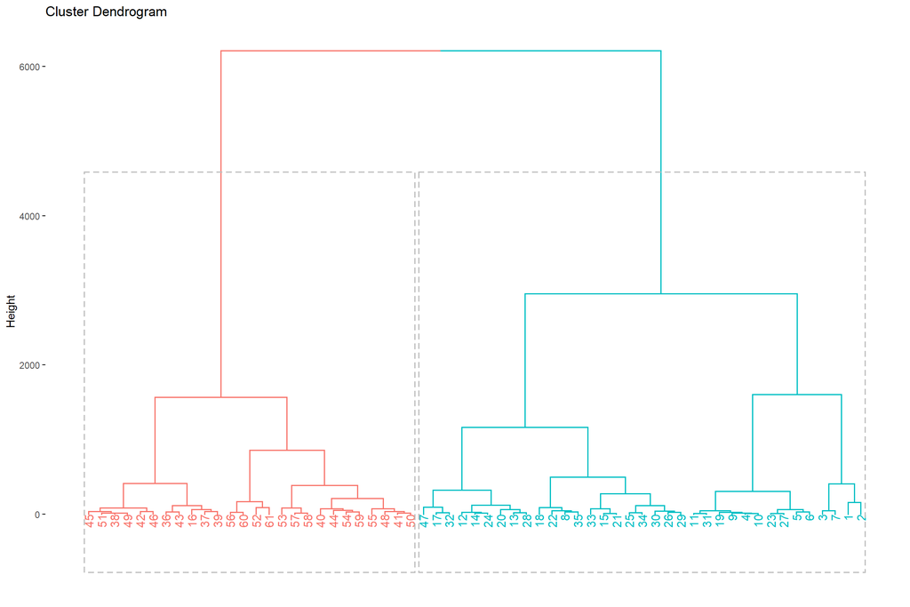

```r
result <- dist(data_cluster, method = "euclidean")
result_hc <- hclust(d = result, method = "ward.D2")
fviz_dend(result_hc, k = 2,
          color_labels_by_k = TRUE,
          rect = TRUE
)
```

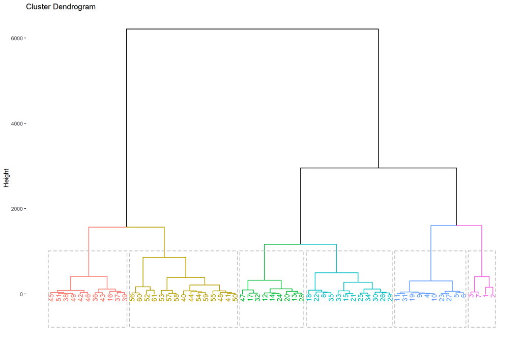

```r
fviz_dend(result_hc, k = 6,
          color_labels_by_k = TRUE,
          rect = TRUE
)
```

As the chart above, there is very little room to divide the sample into six categories, and it would be better to divide it into two categories.

## Conclusion

1. We choose the Euclidean distance to measure the distance because the data are normalised,. The Euclidean distance in vector space can be a good evaluation of the distance between two sample points. Cosine similarity is the spatial vector used to determine the similarity of two sample points. In this task, there are too many sample points and they are relatively discrete, so the cosine similarity is not good.
2. And we then let k = 2 and only divided the data into two classes, which seems so few and also far from the centre. Howerver, as the analysis above, let k = 2 is most suitable for this dataset because of three reasons, which are the CH index, cluster plot and the cluster dendrogram. The CH index is the ratio of separation to tightness. So a larger CH represents a tighter class itself and a more dispersed class to class.
3. Finally, we find that Cluster 1 mainly contains the number of accidents from 2005, with a lower number of accidents, later shift begin time and less work experience. Cluster 2 mainly contains the number of accidents from 2000, with a larger number of accidents, earlier shift begin time and more work experience. This is consistent with our finding in project1 that the number of accidents has decreased over time. However, it seems that the quarter with more accidents also has more mean work experience, which we speculate may be because work experience does not play a big role in the number of accidents. In other words, it mainly depend on the time (the year, quarter and shift time).